# PGY1 Residency Interviews Feedback Survey

## Survey

The survey was conducted in March 2016 via SurveyMonkey. The survey was sent to all 35 candidates who interviewed for the PGY1 Pharmacy Residency for the 2016-2017 residency year. There were 29 candidates who completed the survey, for a response rate of 82.9%.

## Questions

Candidates were asked the following questions:

1. When researching residency programs, how did you first learn about the PGY1 residency program at Memorial Hermann-Texas Medical Center?
2. What factors were most important to you when deciding what order to rank residency programs?
3. How would you rate each of these components of your interview day at Memorial Hermann-Texas Medical Center? (Each item was rated using a Likert scale of: Poor, Below Average, Average, Above Average, Excellent)
   1. Residency Program Director interactions
   2. Preceptor interactions
   3. Resident interactions
   4. Multiple Mini Interviews
   5. Lunch
   6. Tour
4. Did the use of the Multiple Mini Interview format influence the way you ranked the residency program at Memorial Hermann-Texas Medical Center?
   1. Yes, I ranked the program higher
   2. Yes, I ranked the program lower
   3. Yes, I did not rank the program because of the MMI scenarios
   4. No, it did not affect how I ranked the program
5. Where did you rank Memorial Hermann-Texas Medical Center?
   1. First Choice
   2. Second Choice
   3. Third Choice or Below
   4. Did Not Rank
6. If Memorial Hermann-Texas Medical Center was not your first choice, what was the primary reason (or reasons) why?
7. Please provide any suggestions you have to improve the interview process at Memorial Hermann-Texas Medical Center for next year’s residency candidates.

## Results

```r
library(readr)
library(dplyr)
library(tidyr)
library(stringr)
library(ggplot2)
library(tableone)
library(pander)
panderOptions("table.split.table", Inf)
```

```r
responses <- read_csv("survey_responses.csv")
rank_factors <- read_csv("ranking_factors.csv")
scores <- read_csv("interview_interaction_scores.csv")
mh_factors <- read_csv("mh_ranking_factors.csv")
recs <- read_csv("recommendations.csv")
```

### Question 1

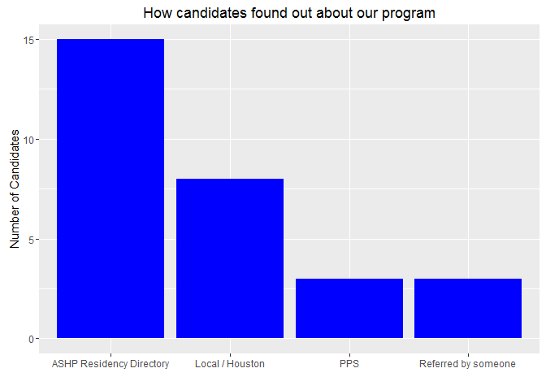

```r
results <- filter(responses, Question == 1) %>%
    mutate(ShortAnswer = str_replace_all(ShortAnswer, "Local / Looking at Houston", "Local / Houston")) %>%
    ggplot(aes(x = ordered(ShortAnswer, levels = names(sort(table(ShortAnswer), decreasing = TRUE))))) +
    geom_bar(fill = "blue") +
    xlab("") +
    ylab("Number of Candidates") +
    ggtitle("How candidates found out about our program")

print(results)
```

### Question 2

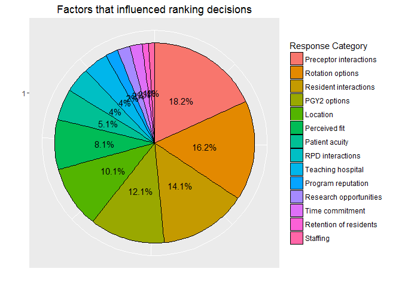

```r
results <- mutate(rank_factors, ResponseType = ordered(ResponseType, levels = names(sort(table(ResponseType), decreasing = TRUE))))

mh_labs <- rank_factors %>%
    group_by(ResponseType) %>%
    summarize(num = n()) %>%
    arrange(desc(num)) %>%
    mutate(ylab = paste0(round((num / sum(num) * 100), 1), "%"),
           yval = cumsum(num) - num / 2)

results <- ggplot(data = results, aes(x = factor(1), fill = ResponseType)) +
    geom_bar(width = 1, color = "black") +
    geom_text(data = mh_labs, aes(x = factor(1), y = yval, label = ylab)) +
    coord_polar(theta = "y") +
    xlab("") +
    ylab("") +
    ggtitle("Factors that influenced ranking decisions") +
    labs(fill = "Response Category") +
    theme(axis.text.x = element_blank())

print(results)
```

### Question 3

**Ratings of each component of the interview day**

```r
results <- mutate(scores, Score = ordered(Score, levels = c("Poor", "Below Average", "Average", "Above Average", "Excellent")),
                 Attribute = str_replace_all(Attribute, " interactions", ""),
                 Attribute = str_replace_all(Attribute, "Residency Program Director", "RPD"),
                 Attribute = str_replace_all(Attribute, "Multiple Mini Interviews", "MMI"))

attributes <- CreateTableOne(data = results, strata = "Attribute", vars = "Score", test = FALSE)
results <- print(attributes, printToggle = FALSE)
pander(results)
```

|  | Lunch | MMI | Preceptor | Resident | RPD | Tour |
| --- | --- | --- | --- | --- | --- | --- |
| **n** | 29 | 29 | 29 | 29 | 29 | 29 |
| **Score (%)** |  |  |  |  |  |  |
| **Poor** | 0 ( 0.0) | 0 ( 0.0) | 0 ( 0.0) | 1 ( 3.4) | 0 ( 0.0) | 1 ( 3.4) |
| **Below Average** | 0 ( 0.0) | 1 ( 3.4) | 0 ( 0.0) | 3 (10.3) | 2 ( 6.9) | 1 ( 3.4) |
| **Average** | 15 (51.7) | 8 (27.6) | 7 (24.1) | 4 (13.8) | 10 (34.5) | 6 (20.7) |
| **Above Average** | 8 (27.6) | 15 (51.7) | 11 (37.9) | 11 (37.9) | 4 (13.8) | 7 (24.1) |
| **Excellent** | 6 (20.7) | 5 (17.2) | 11 (37.9) | 10 (34.5) | 13 (44.8) | 14 (48.3) |

### Question 4

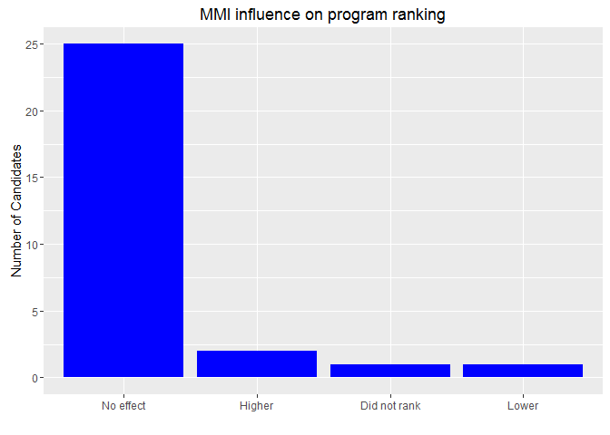

```r
results <- filter(responses, Question == 4) %>%
    mutate(ShortAnswer = str_replace_all(ShortAnswer, "No, it did not affect how I ranked the program", "No effect"),
           ShortAnswer = str_replace_all(ShortAnswer, "Yes, I ranked the program higher", "Higher"),
           ShortAnswer = str_replace_all(ShortAnswer, "Yes, I ranked the program lower", "Lower"),
           ShortAnswer = str_replace_all(ShortAnswer, "Yes, I did not rank the program because of the MMI scenarios", "Did not rank")) %>%
    ggplot(aes(x = ordered(ShortAnswer, levels = names(sort(table(ShortAnswer), decreasing = TRUE))))) +
    geom_bar(fill = "blue") +
    xlab("") +
    ylab("Number of Candidates") +
    ggtitle("MMI influence on program ranking")

print(results)
```

### Question 5

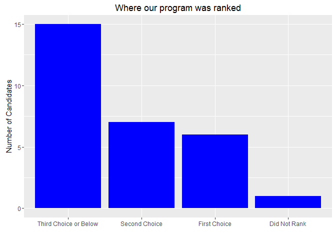

```r
results <- filter(responses, Question == 5) %>%
    ggplot(aes(x = ordered(ShortAnswer, levels = names(sort(table(ShortAnswer), decreasing = TRUE))))) +
    geom_bar(fill = "blue") +
    xlab("") +
    ylab("Number of Candidates") +
    ggtitle("Where our program was ranked")

print(results)
```

### Question 6

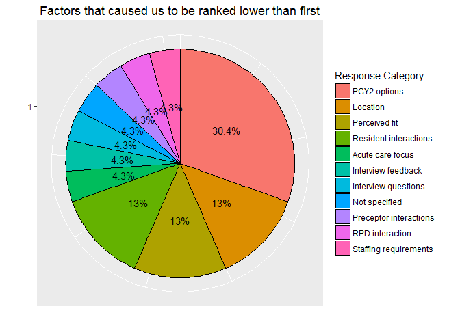

```r
results <- mutate(mh_factors, ResponseType = ordered(ResponseType, levels = names(sort(table(ResponseType), decreasing = TRUE))))

mh_labs <- mh_factors %>%
    group_by(ResponseType) %>%
    summarize(num = n()) %>%
    arrange(desc(num)) %>%
    mutate(ylab = paste0(round((num / sum(num) * 100), 1), "%"),
           yval = cumsum(num) - num / 2)

results <- ggplot(data = results, aes(x = factor(1), fill = ResponseType)) +
    geom_bar(width = 1, color = "black") +
    geom_text(data = mh_labs, aes(x = factor(1), y = yval, label = ylab)) +
    coord_polar(theta = "y") +
    xlab("") +
    ylab("") +
    ggtitle("Factors that caused us to be ranked lower than first") +
    labs(fill = "Response Category") +
    theme(axis.text.x = element_blank())

print(results)
```

### Question 7

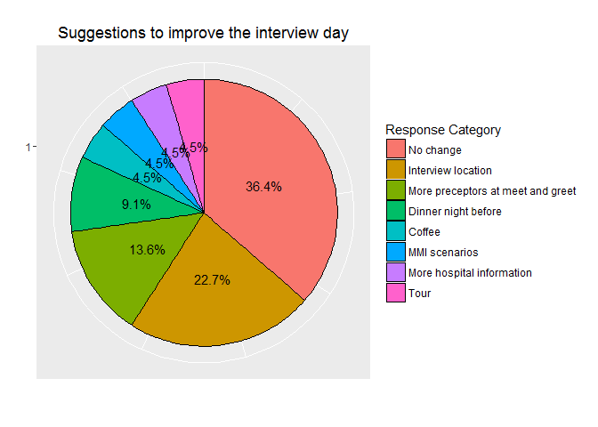

```r
results <- mutate(recs, ResponseType = ordered(ResponseType, levels = names(sort(table(ResponseType), decreasing = TRUE))))

mh_labs <- recs %>%
    group_by(ResponseType) %>%
    summarize(num = n()) %>%
    arrange(desc(num)) %>%
    mutate(ylab = paste0(round((num / sum(num) * 100), 1), "%"),
           yval = cumsum(num) - num / 2)

results <- ggplot(data = results, aes(x = factor(1), fill = ResponseType)) +
    geom_bar(width = 1, color = "black") +
    geom_text(data = mh_labs, aes(x = factor(1), y = yval, label = ylab)) +
    coord_polar(theta = "y") +
    xlab("") +
    ylab("") +
    ggtitle("Suggestions to improve the interview day") +
    labs(fill = "Response Category") +
    theme(axis.text.x = element_blank())

print(results)
```